# Project_1

Maximiliano

7/6/2020

# Project 1 Reproducible Research Coursera

This assignment makes use of data from a personal activity monitoring device. This device collects data at 5 minute intervals through out the day. The data consists of two months of data from an anonymous individual collected during the months of October and November, 2012 and include the number of steps taken in 5 minute intervals each day.

### Read data

```r
activity<-read.csv("activity.csv", na.strings = "NA")
```

### Calculate the total number of steps per day

```r
activity_complete <- activity[complete.cases(activity),]
steps_day <- aggregate(steps~date, activity_complete,sum)
```

## Histogram of steps per day

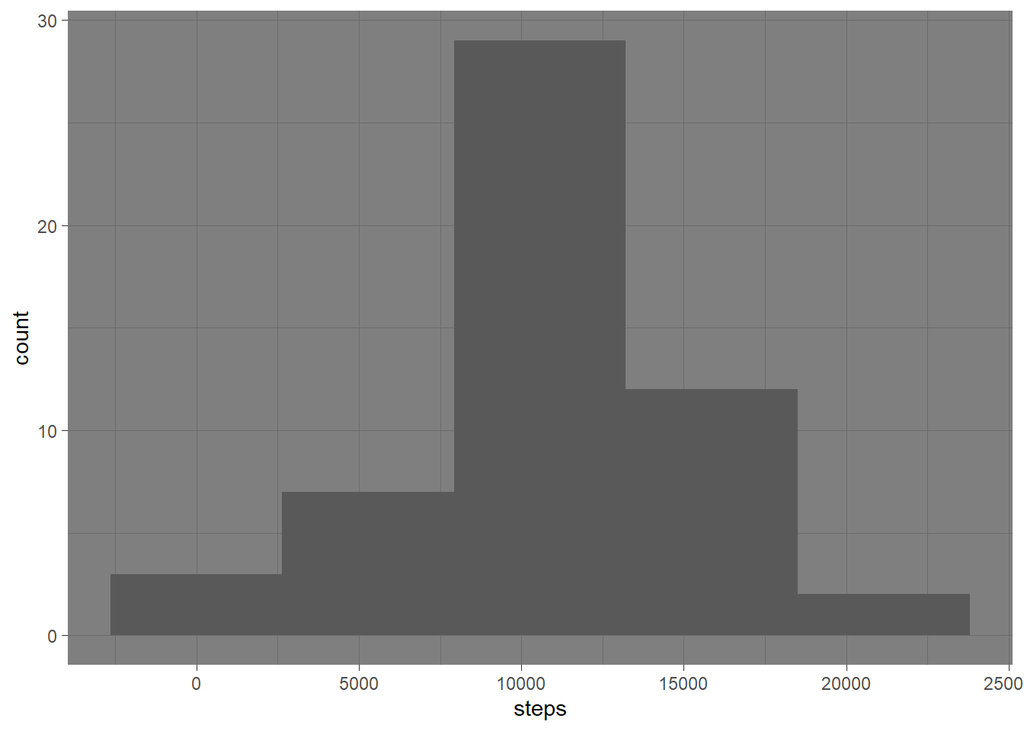

```r
library(ggplot2)
ggplot(steps_day, aes(x=steps)) + geom_histogram(bins=5) + theme_dark()
```

### Mean and median of total steps taken per day

```r
#Mean
round(mean(steps_day$steps))
```

```
## [1] 10766
```

```r
#median
round(median(steps_day$steps))
```

```
## [1] 10765
```

### Calculate the mean steps per interval

```r
steps_interval <- aggregate(steps ~ interval, activity_complete, mean)
```

### Plot time series of the 5-minute interval (x-axis) and the average number of steps taken, averaged across all days (y-axis)

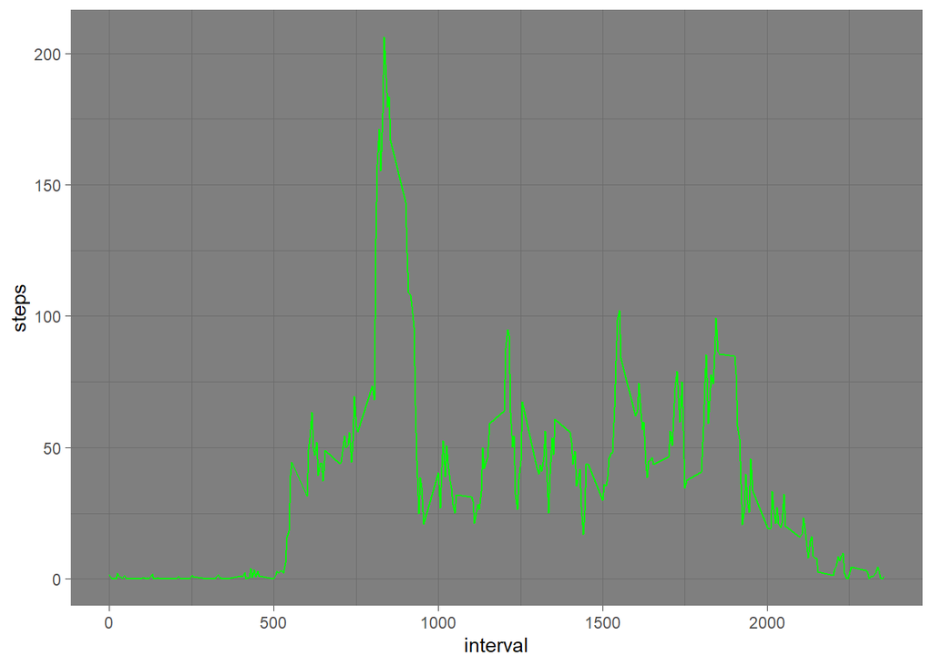

```r
ggplot(data=steps_interval, aes(y=steps, x=interval)) + geom_line(colour="green") + theme_dark()
```

### Which 5-minute interval, on average across all the days in the dataset, contains the maximum number of steps?

```r
max_interval <- which.max(steps_interval$steps)
steps_interval[max_interval,]
```

```
##     interval    steps
## 104      835 206.1698
```

## Working with NA.

### Imputing missing values. Calculate the number of rows with missing values in steps column

```r
missing_steps_values<-activity[!complete.cases(activity),]
#Number of empty rows
nrow(missing_steps_values)
```

```
## [1] 2304
```

These missing values will be replaced with the mean of the 5 minute interval

```r
#Create new data with NA replaced

activity_replacedNA <- activity

for (i in 1:nrow(activity_replacedNA)) {
  if(is.na(activity_replacedNA$steps[i])) {
    avg_value <- steps_interval$steps[which(steps_interval$interval == activity_replacedNA$interval[i])]
    activity_replacedNA$steps[i] <- avg_value
  }
}


steps_day_filledNA <- aggregate(steps~date, activity_replacedNA,sum)
```

### Plot histogram of steps per day

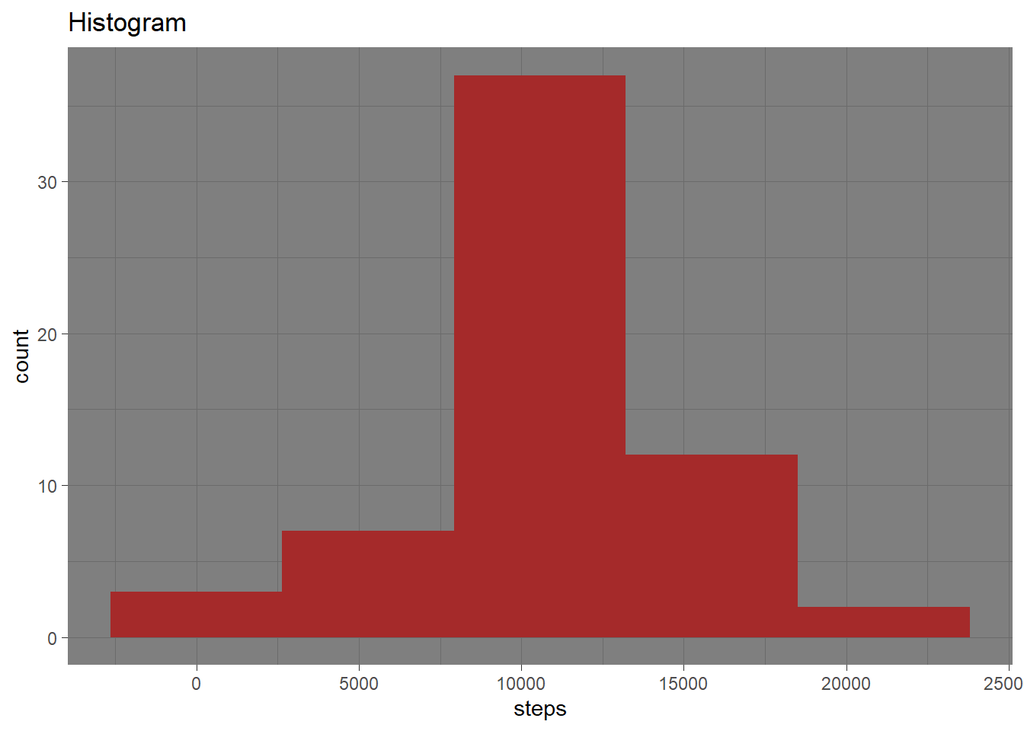

```r
ggplot(steps_day_filledNA, aes(x=steps)) + geom_histogram(bins=5, fill="brown") + ggtitle("Histogram") + theme_dark()
```

### Mean and median of total of steps taken per day with NA replaced

```r
#Mean of total of steps taken per day
round(mean(steps_day_filledNA$steps))
```

```
## [1] 10766
```

```r
#Median of total of steps taken per day

round(median(steps_day_filledNA$steps))
```

```
## [1] 10766
```

As seen from the previous data, the mean and median are the same after replacing the NA with the mean data of the 5 minute interval

## Are there differences in activity patterns between weekdays and weekends?

### First create factor of weekday and weekend

```r
activity_complete$weekday <- ifelse(weekdays(as.Date(activity_complete$date))
                                    %in% c("sábado", "domingo"),
                              "weekend", "weekdays")

steps_day_week <- aggregate(steps ~ interval + weekday, data = activity_complete, mean)
```

### Plot data by days

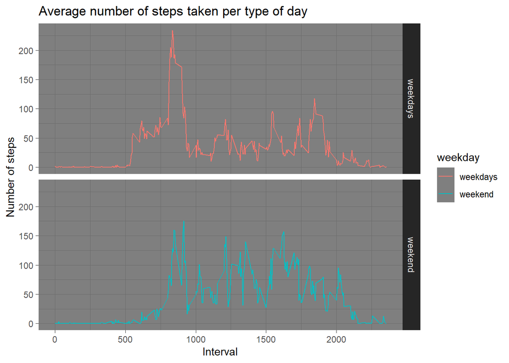

```r
ggplot(steps_day_week, aes(interval, steps)) +
  geom_line(stat = "identity", aes(colour = weekday)) +
  facet_grid(weekday ~ ., scales="fixed", space="fixed") +
  labs(x="Interval", y=("Number of steps")) +
  ggtitle("Average number of steps taken per type of day")+theme_dark()
```

The pattern between weekdays and weekend differ.